# Differential Abundance Analysis

Yixuan Yang

# Set Up

```r
rm(list = ls())
set.seed(2024)
library(tidyverse)
library(phyloseq)
library(here)
library(gt)
library(GGally)
library(ggcorrplot)
theme_set(theme_bw())

# DA tools
library(ALDEx2)
library(ANCOMBC)
library(corncob)
library(MicrobiomeStat) # for Linda

ps <- readRDS(here('data','following_study','ps.rds'))
ps.rare <- readRDS(here('data','following_study','ps_rarefied.rds'))
ps.present <- ps %>% transform_sample_counts(sign)

alpha <- 0.05
max.cores <- parallel::detectCores()
```

# Taxa Filtering

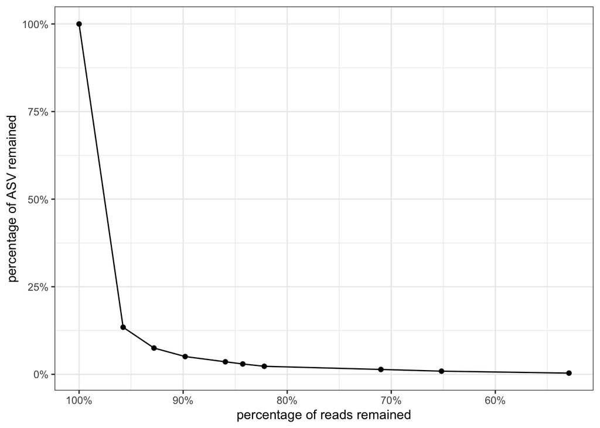

```r
# test for filtering threshold
test.filter <- function(ps, prevlence, min_read = 0) {
    sub.ps <- ps %>%
      filter_taxa(function(x) sum(x)>min_read & sum(x>0)/length(x) >= prevlence, prune = TRUE)
    retained.read <- otu_table(sub.ps) %>% rowSums() %>% mean()
    retained.taxa <- otu_table(sub.ps) %>% ncol()
    orig.read <- otu_table(ps) %>% rowSums() %>% mean()
    orig.taxa <- otu_table(ps) %>% ncol()
    return(data.frame(taxon_size = retained.taxa/orig.taxa, average.read.depth = retained.read/orig.read))
}
trace <- map_dfr(seq(0,0.9, 0.1), function(i) test.filter(ps=ps, prevlence=i))

ggplot(trace, aes(x = average.read.depth, y = taxon_size)) +
    geom_point() +
    geom_line() +
    scale_x_reverse(labels = scales::percent) +
    scale_y_continuous(labels = scales::percent) +
    xlab('percentage of reads remained') +
    ylab('percentage of ASV remained')
```

```r
head(trace)
```

```
##   taxon_size average.read.depth
## 1 1.00000000          1.0000000
## 2 0.13442167          0.9576704
## 3 0.07502605          0.9280344
## 4 0.05071205          0.8980429
## 5 0.03577631          0.8594170
## 6 0.02952414          0.8426915
```

```r
keep <- ps %>%
  filter_taxa(function(x) sum(x>0)/length(x)>0.1, prune = TRUE) %>%
  tax_table() %>% rownames()
```

Basic information of non-rarefied data

```r
ps <- ps %>% prune_taxa(keep, .)
ps
```

```
## phyloseq-class experiment-level object
## otu_table()   OTU Table:         [ 387 taxa and 98 samples ]
## sample_data() Sample Data:       [ 98 samples by 28 sample variables ]
## tax_table()   Taxonomy Table:    [ 387 taxa by 7 taxonomic ranks ]
## phy_tree()    Phylogenetic Tree: [ 387 tips and 386 internal nodes ]
## refseq()      DNAStringSet:      [ 387 reference sequences ]
```

Basic information of rarefied data

```r
ps.rare <- ps.rare %>% prune_taxa(keep, .)
ps.rare
```

```
## phyloseq-class experiment-level object
## otu_table()   OTU Table:         [ 387 taxa and 98 samples ]
## sample_data() Sample Data:       [ 98 samples by 28 sample variables ]
## tax_table()   Taxonomy Table:    [ 387 taxa by 7 taxonomic ranks ]
## phy_tree()    Phylogenetic Tree: [ 387 tips and 386 internal nodes ]
## refseq()      DNAStringSet:      [ 387 reference sequences ]
```

# Differential Abundance Analysis

## ALDEx2

### pairwise T-test

```r
clr.data <- aldex.clr(t(otu_table(ps)), as.character(sample_data(ps)$Epileptic.or.Control), mc.samples=128, denom="all")

aldex.t.test.p <- aldex.ttest(clr.data, paired.test = TRUE)
aldex.t.test.effect <- aldex.effect(clr.data, paired.test = TRUE, useMC = TRUE, verbose = FALSE)

if (!identical(rownames(aldex.t.test.p), rownames(aldex.t.test.effect))) stop('taxa names are not matched')
aldex.t.test <- data.frame(aldex.t.test.p, aldex.t.test.effect) %>%
  rownames_to_column('taxon') %>%
  mutate(LFC = rab.win.Epileptic - rab.win.Control) %>%
  mutate(p.value = we.ep) %>%
  dplyr::select(taxon, LFC, p.value)

aldex.t.test %>% arrange(str_rank(taxon, numeric = TRUE)) %>% head()
```

```
##   taxon         LFC     p.value
## 1  ASV1 -0.05952564 0.686929409
## 2  ASV2  0.28095678 0.007961295
## 3  ASV3  0.17524459 0.848390423
## 4  ASV4 -0.04808613 0.538993838
## 5  ASV5 -1.14280561 0.276980164
## 6  ASV6  0.65206133 0.032268942
```

### GLM test

```r
model <- model.matrix(~ Epileptic.or.Control + Household, data.frame(sample_data(ps)))
clr.data <- aldex.clr(t(otu_table(ps)), model, mc.samples=128, denom="all")

aldex.glm.test.p <- aldex.glm(clr.data, model)
```

```
## |------------(25%)----------(50%)----------(75%)----------|
```

```r
aldex.glm.test.effect <- aldex.glm.effect(clr.data, verbose = FALSE, useMC = TRUE)$Epileptic.or.ControlEpileptic
if (!identical(rownames(aldex.glm.test.p), rownames(aldex.glm.test.effect))) stop('taxa names are not matched')

aldex.glm.test <- data.frame(p.value = aldex.glm.test.p$`Epileptic.or.ControlEpileptic:pval`, aldex.glm.test.effect) %>%
    rownames_to_column('taxon') %>%
    mutate(LFC = rab.win.1 - rab.win.0) %>% # 0 is control, 1 is epileptic, set is `data-cleaning.Rmd`
    dplyr::select(taxon, LFC, p.value)

aldex.glm.test %>% arrange(str_rank(taxon, numeric = TRUE)) %>% head()
```

```
##   taxon         LFC     p.value
## 1  ASV1 -0.03414324 0.681977030
## 2  ASV2  0.24792837 0.007521401
## 3  ASV3  0.18789559 0.859989678
## 4  ASV4 -0.03754511 0.542065670
## 5  ASV5 -1.14198778 0.241079468
## 6  ASV6  0.66082144 0.030846682
```

## ANCOMBC

```r
ancombc.test <- ancombc(data = ps,
                        formula = 'Epileptic.or.Control + Household',
                        taxa_are_rows = FALSE,
                        prv_cut = 0,
                        conserve = TRUE,
                        n_cl = max.cores)

ancombc.test <- data.frame(taxon = ancombc.test$res$lfc$taxon,
                           # convert logfold change to log2fold change
                           LFC = log2(exp(ancombc.test$res$lfc$Epileptic.or.ControlEpileptic)),
                           p.value = ancombc.test$res$p_val$Epileptic.or.ControlEpileptic)

ancombc.test %>% arrange(str_rank(taxon, numeric = TRUE)) %>% head
```

```
##   taxon         LFC      p.value
## 1  ASV1 -0.02483695 0.8989784944
## 2  ASV2  0.76488405 0.0005426785
## 3  ASV3 -0.14919417 0.5991345418
## 4  ASV4 -0.35090932 0.1478109441
## 5  ASV5 -0.80988944 0.0177297871
## 6  ASV6  0.44661012 0.0156575090
```

## corncob

```r
corncob.test <- differentialTest(formula= ~ Epileptic.or.Control + Household,
                                 phi.formula = ~ 1,
                                 formula_null = ~ Household,
                                 phi.formula_null = ~ 1,
                                 test = 'LRT',
                                 fdr_cutoff = 1, # don't filter by FDR
                                 data = ps,
                                 taxa_are_rows = FALSE)

# convert corcob result to log2fold difference
corncob.extract.result <- function(corncob.da, i) {
    regression.result <- corncob.da$all_models[[i]]$coefficients
    # p value
    p <- corncob.da$p[i]
    # relative abundance
    RA.ctl <- regression.result['mu.(Intercept)','Estimate'] %>% invlogit()
    RA.epi <- regression.result[c('mu.(Intercept)','mu.Epileptic.or.ControlEpileptic'),'Estimate'] %>% sum() %>% invlogit()
    LFC <- RA.epi - RA.ctl # NOTE: this is not log2fold change, but the difference of relative abundance, since corncob does not provide lfc.
    summary <- data.frame(LFC = LFC, p.value = p) %>% rownames_to_column('taxon')
    return(summary)
}
corncob.test <- map_dfr(1:length(taxa_names(ps)), function(i) corncob.extract.result(corncob.test, i))
corncob.test %>%
  arrange(str_rank(taxon, numeric = TRUE)) %>%
  mutate(`relative abundance difference`= LFC) %>% dplyr::select(-LFC) %>% head
```

```
##   taxon      p.value relative abundance difference
## 1  ASV1 0.7569841965                   0.006657252
## 2  ASV2 0.0002559817                   0.019875019
## 3  ASV3 0.6072699142                   0.005305560
## 4  ASV4 0.4849536685                   0.002897453
## 5  ASV5 0.0101062035                  -0.008041232
## 6  ASV6 0.0087398620                   0.010164788
```

## LinDA

```r
linda.test <- linda(t(data.frame(otu_table(ps))),
                   data.frame(sample_data(ps)),
                   formula = '~ Epileptic.or.Control + Household',
                   feature.dat.type = 'count',
                   n.cores = max.cores,
                   verbose = FALSE)

linda.test <- linda.test$output$Epileptic.or.ControlEpileptic %>%
    dplyr::select(log2FoldChange, pvalue) %>%
    rownames_to_column('taxon')
colnames(linda.test)[2:3] <- c('LFC', 'p.value')

linda.test %>% arrange(str_rank(taxon, numeric = TRUE)) %>% head()
```

```
##   taxon          LFC    p.value
## 1  ASV1  0.008832133 0.97362763
## 2  ASV2  0.828567789 0.01110301
## 3  ASV3 -0.113867747 0.77997430
## 4  ASV4 -0.306886536 0.36471738
## 5  ASV5 -0.727514458 0.12941569
## 6  ASV6  0.505157615 0.04603249
```

## pairwise T-test on rarefied data

```r
paired.t.test <- function(data, pseudo.count = 0.5) {
    splited.data <- data %>%
        arrange(Household, Epileptic.or.Control) %>%
        split(.$Epileptic.or.Control)
    t.test.result <- t.test(splited.data[['Epileptic']]$Abundance,
                            splited.data[['Control']]$Abundance,
                            paired = TRUE, alternative = 'two.sided')
    data.frame(taxon = unique(data$OTU),
               LFC = mean(log2(splited.data[['Epileptic']]$Abundance + pseudo.count) - log2(splited.data[['Control']]$Abundance + pseudo.count)),
               p.value = t.test.result$p.value)
}

pairwise.t.test <- psmelt(ps.rare) %>%
    group_by(OTU) %>%
    group_split() %>%
    map_dfr(paired.t.test)

pairwise.t.test %>% arrange(str_rank(taxon, numeric = TRUE)) %>% head()
```

```
##   taxon         LFC    p.value
## 1  ASV1  0.08532570 0.88527495
## 2  ASV2  0.88582424 0.01093835
## 3  ASV3 -0.03860217 0.93203722
## 4  ASV4 -0.27082143 0.76325632
## 5  ASV5 -0.66961126 0.03099468
## 6  ASV6  0.53771013 0.17916855
```

# Comparative Analysis

Here we compare the results of different methods. We first show the top 10 ASVs with the smallest p-value for each method.

```r
test.results <- list("ALDEx2 t-test" = aldex.t.test,
                     "ALDEx2 GLM" = aldex.glm.test,
                     "ANCOM-BC" = ancombc.test,
                     "corncob" = corncob.test,
                     "LinDA" = linda.test,
                     "paired t-test" = pairwise.t.test) %>%
    bind_rows(.id = 'method') %>%
    group_by(method) %>% arrange(str_rank(taxon, numeric = TRUE)) %>% ungroup()

tax <- tax_table(ps) %>%
    as.data.frame() %>%
    dplyr::select(Phylum, Genus) %>%
    rownames_to_column('taxon')

p.value.tb <- test.results %>%
    dplyr::select(taxon, method, p.value) %>%
    pivot_wider(names_from = method, values_from = p.value) %>%
    rowwise() %>%
    mutate(SignificantCount = sum(c_across(-taxon) < alpha))

top.p <- p.value.tb %>%
    left_join(tax,., by = 'taxon') %>%
    group_by(SignificantCount) %>%
    arrange(str_rank(taxon, numeric = TRUE), .by_group = TRUE) %>%
    arrange(desc(SignificantCount)) %>%
    ungroup() %>%
    dplyr::select(-SignificantCount)

tb <- top.p %>%
    head(10) %>%
    gt() %>%
    fmt_number(decimals = 4) %>%
    tab_style_body(
    columns = where(is.numeric),
    style = cell_text(weight = "bold"),
    fn = function(x) x <= alpha
  )
tb
```

| taxon | Phylum | Genus | ALDEx2 t-test | ALDEx2 GLM | ANCOM-BC | corncob | LinDA | paired t-test |
| --- | --- | --- | --- | --- | --- | --- | --- | --- |
| ASV2 | Actinobacteriota | Collinsella | 0.0080 | 0.0075 | 0.0005 | 0.0003 | 0.0111 | 0.0109 |
| ASV6 | Firmicutes | [Ruminococcus] gnavus group | 0.0323 | 0.0308 | 0.0157 | 0.0087 | 0.0460 | 0.1792 |
| ASV42 | Firmicutes | [Ruminococcus] torques group | 0.0892 | 0.0830 | 0.0001 | 0.0403 | 0.0158 | 0.0398 |
| ASV100 | Firmicutes | Lachnoclostridium | 0.1795 | 0.1688 | 0.0001 | 0.0001 | 0.0151 | 0.0111 |
| ASV420 | Firmicutes | Clostridium sensu stricto 1 | 0.1596 | 0.1502 | 0.0010 | 0.0001 | 0.0183 | 0.0288 |
| ASV446 | NA | NA | 0.1204 | 0.1121 | 0.0008 | 0.0002 | 0.0124 | 0.0340 |
| ASV645 | Firmicutes | NA | 0.3842 | 0.4280 | 0.0004 | 0.0002 | 0.0158 | 0.0292 |
| ASV702 | Firmicutes | Holdemania | 0.5177 | 0.4372 | 0.0000 | 0.0000 | 0.0086 | 0.0209 |
| ASV5 | Fusobacteriota | Fusobacterium | 0.2770 | 0.2411 | 0.0177 | 0.0101 | 0.1294 | 0.0310 |
| ASV12 | Firmicutes | Blautia | 0.1156 | 0.1222 | 0.0003 | 0.0355 | 0.0172 | 0.1086 |

There are 2 ASVs that are not classified to genus level by the naive bayes classifier. Here we search it with the BLAST nt/nr database

```r
refseq(ps)[c('ASV446', 'ASV645')] %>% dada2:::pfasta(ids = c('ASV446', 'ASV645'))
```

```
## >ASV446
## TCCTGTTTGCTCCCCACGCTTTCGAGCCTCAACGTCAGTCATCGTCCAGAAAGCCGCCTT…
## >ASV645
## TACGTAGGGGGCAAGCGTTATCCGGATTTACTGGGTGTAAAGGGAGCGTAGACGGCGCAG…
```

For ASV446, the top hit is Firmicutes, Mediterraneibacter (Phylum, Genus)

For ASV645, the top hit is Firmicutes, Lachnospiraceae (Phylum, Family)

Does the effect size of each method agreed in direction? The plot below shows that including `corncob` all methods have consistent direction of effect size.

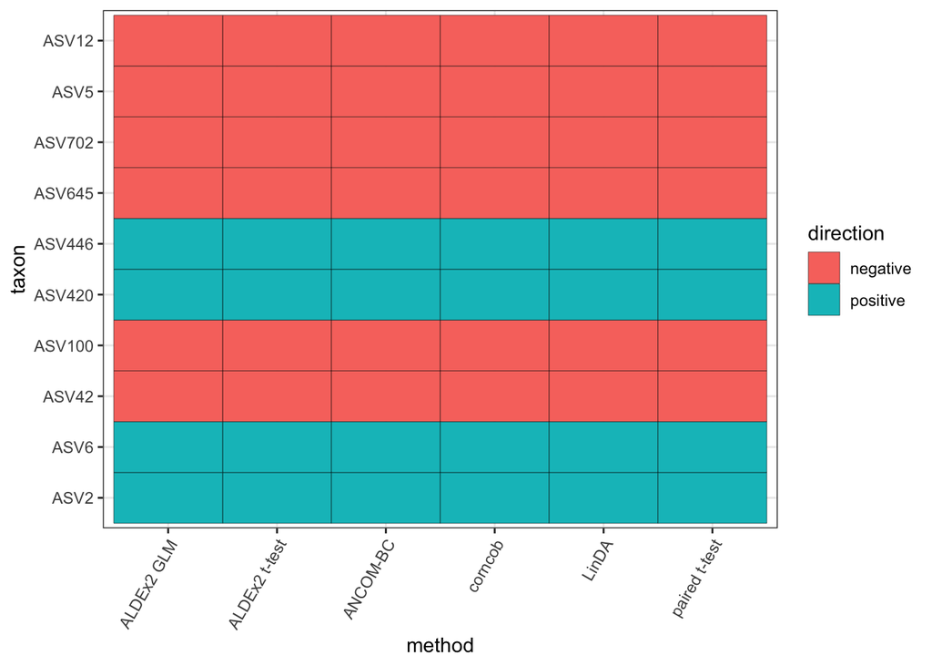

```r
test.results$taxon <- factor(test.results$taxon,
                             levels = top.p$taxon)
test.results %>%
    mutate(direction = if_else(LFC > 0, 'positive', 'negative')) %>%
    filter(taxon %in% head(top.p$taxon, 10)) %>%
    ggplot() +
    geom_tile(aes(x = method, y = taxon, fill = direction), color = 'black') +
    theme(axis.text.x = element_text(angle = 60, hjust = 1))
```

Effect size of top 10 ASVs for each method.

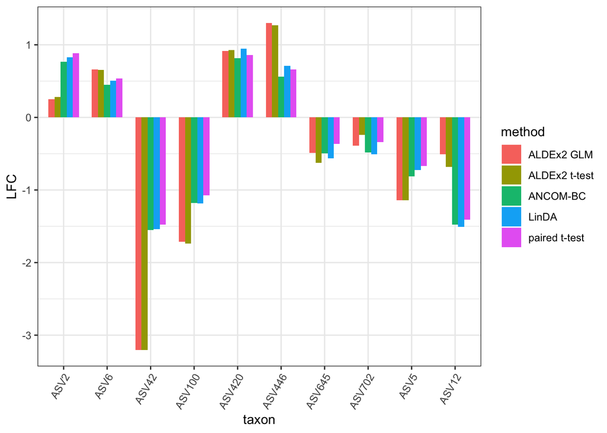

```r
effect.plot <- test.results %>%
    filter(method != 'corncob') %>%
    filter(taxon %in% head(top.p$taxon, 10)) %>%
    ggplot() +
        geom_bar(aes(x = taxon, y = LFC, fill = method),
                 position="dodge", stat = 'identity', width = 0.7) +
        theme(axis.text.x = element_text(angle = 60, hjust = 1))
effect.plot
```

correlation of p-value for each method.

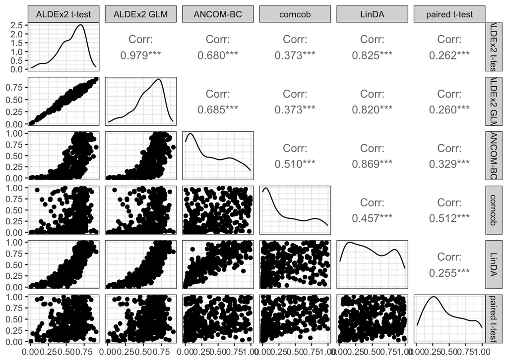

```r
top.p %>%
    dplyr::select(-c(Phylum, Genus)) %>%
    column_to_rownames('taxon') %>%
    ggpairs(progress = FALSE)
```

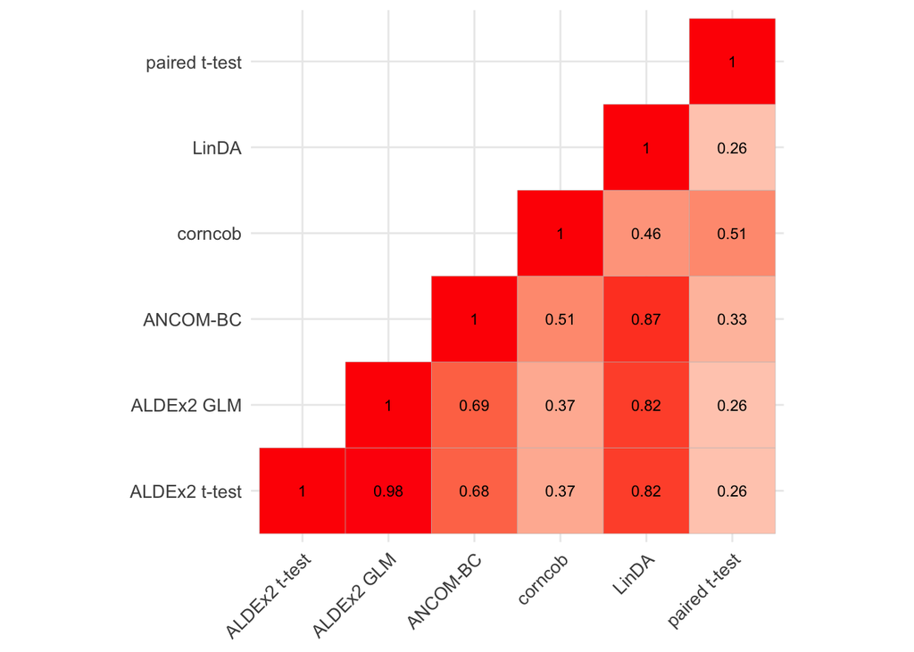

```r
cor.plot <- top.p %>%
    dplyr::select(-c(Phylum, Genus)) %>%
    column_to_rownames('taxon') %>%
    cor() %>%
    ggcorrplot(lab = TRUE,
               lab_size = 3,
               type = 'lower',
               show.diag = TRUE,
               show.legend = FALSE,
               tl.cex = 10)
cor.plot
```

Volcano plots

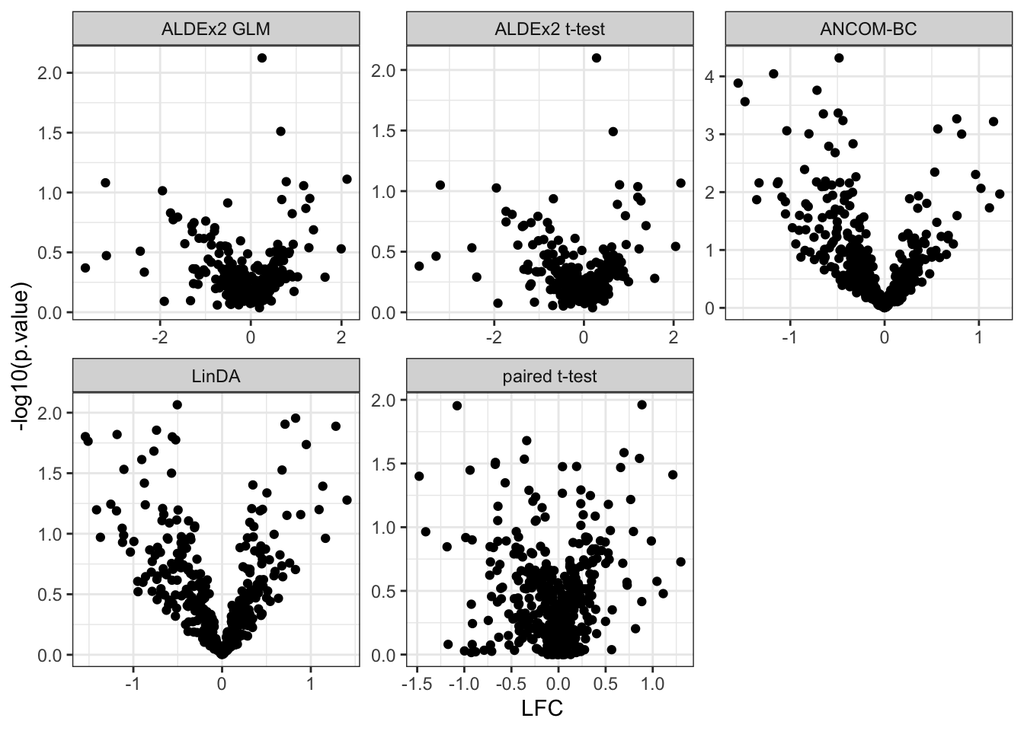

```r
test.results %>%
  filter(method != 'corncob') %>%
  ggplot() +
  geom_point(aes(x = LFC, y = -log10(p.value))) +
  facet_wrap(~method, scales = 'free')
```